# Making Maps with R

Friday, June 19, 2015

## Making Maps with R

- rworldmap
- ggmaps

## Setup your packages

```r
## If necessary
install.packages(c("rworldmap", "rworldxtra", "RColorBrewer",
    "maptools", "classInt"))

## Load packages
library('rworldmap')
library('rworldxtra')
library('RColorBrewer')
library('maptools')
library('classInt')
```

## Load the map data

First we need to load the data. For this we will be using data provided by the package `rworldmap` for our maps. You can do the same thing with your own map files or using packages that use freely available maps, like `Google Maps` or `OpenStreetMap` (https://www.openstreetmap.org).

```r
worldmap <- getMap(resolution = "high")
dim(worldmap)
```

```
## [1] 253  51
```

## What's in the data object

```r
names(worldmap)
```

```
##  [1] "ne_10m_adm"   "ScaleRank"    "LabelRank"    "FeatureCla"
##  [5] "OID_"         "SOVEREIGNT"   "SOV_A3"       "ADM0_DIF"
##  [9] "LEVEL"        "TYPE"         "ADMIN"        "ADM0_A3"
## [13] "GEOU_DIF"     "GEOUNIT"      "GU_A3"        "SU_DIF"
## [17] "SUBUNIT"      "SU_A3"        "NAME"         "ABBREV"
## [21] "POSTAL"       "NAME_FORMA"   "TERR_"        "NAME_SORT"
## [25] "MAP_COLOR"    "POP_EST"      "GDP_MD_EST"   "FIPS_10_"
## [29] "ISO_A2"       "ISO_A3"       "ISO_N3"       "ISO3"
## [33] "LON"          "LAT"          "ISO3.1"       "ADMIN.1"
## [37] "REGION"       "continent"    "GEO3major"    "GEO3"
## [41] "IMAGE24"      "GLOCAF"       "Stern"        "SRESmajor"
## [45] "SRES"         "GBD"          "AVOIDnumeric" "AVOIDname"
## [49] "LDC"          "SID"          "LLDC"
```

## Plot the world

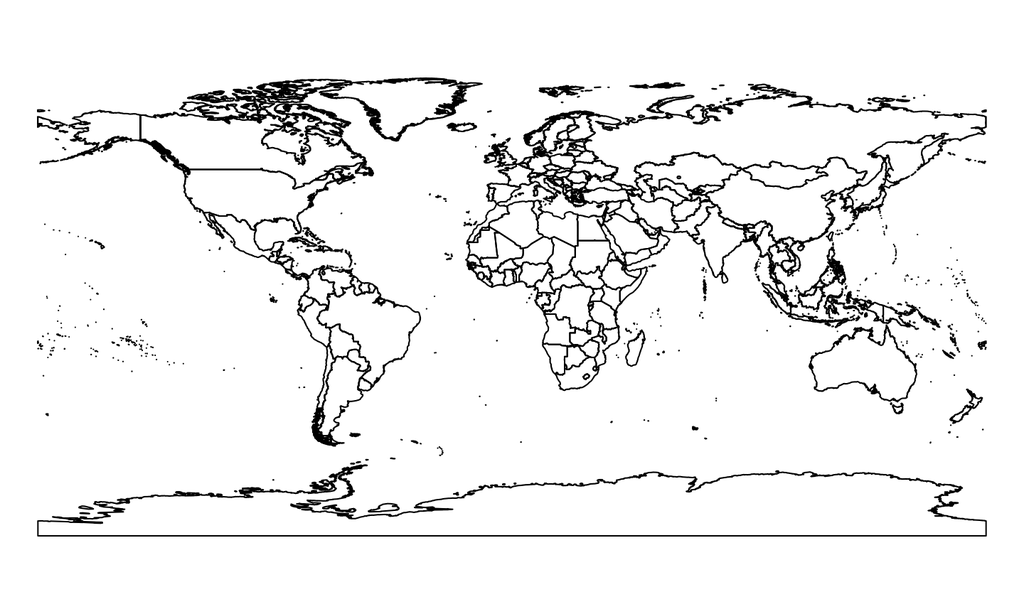

```r
par(mar=c(0,0,0,0))     # Set 0 margins
plot(worldmap)          # Plot
```

## Plot a smaller area

Setting the `xlim` and `ylim` sets our plotted area to a specific limit of lattitude and longitude coordinates.

- ylim = Lattitude
- xlim = Longitude

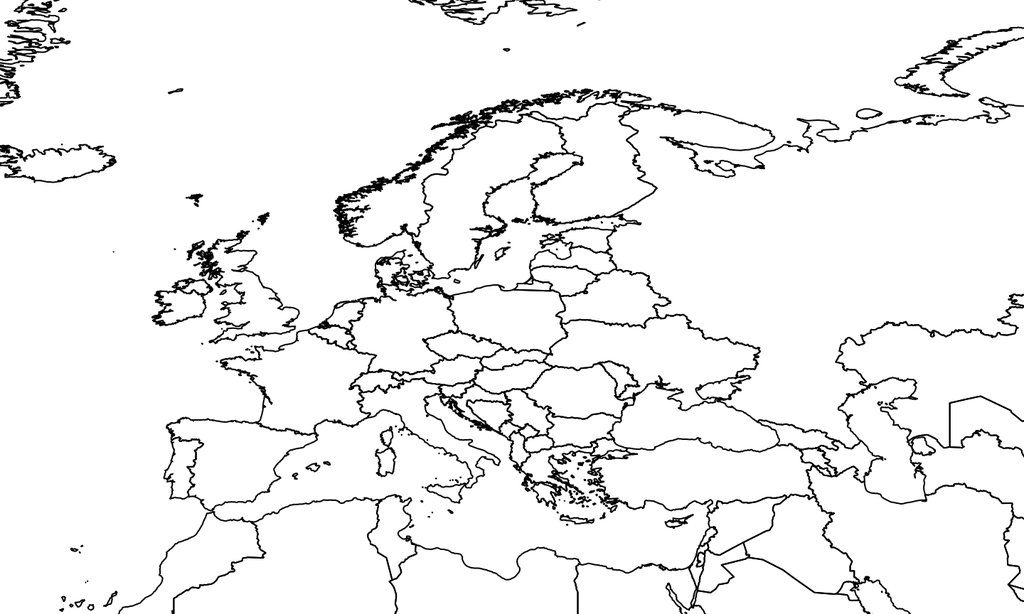

```r
par(mar=c(0,0,0,0))     # Set 0 margins
plot(worldmap, xlim = c(-20, 59), ylim = c(35, 71), asp = 1)
```

## Plot a Region, Country, or other Area

We can also select only certain regions or countries if we want.

```r
t(t(table(worldmap$REGION)))
```

```
##
##                                   [,1]
##   Africa                            57
##   Antarctica                         1
##   Asia                              46
##   Australia                         27
##   Europe                            70
##   North America                      5
##   South America and the Caribbean   44
```

## More

```r
table(worldmap$GEO3)
```

```
##
##                 Antarctic         Arabian Peninsula
##                         1                         6
## Australia and New Zealand                    Canada
##                         5                         2
##                 Caribbean            Central Africa
##                        23                         9
##              Central Asia            Central Europe
##                         5                        21
##            Eastern Africa            Eastern Europe
##                         9                         8
##                   Mashriq              Meso-America
##                         5                         8
##              North Africa  NW Pacific and East Asia
##                         8                         9
##                     Polar             South America
##                         1                        13
##                South Asia             South Pacific
##                        10                        22
##            Southeast Asia           Southern Africa
##                        11                        12
##                        US            Western Africa
##                         3                        15
##            Western Europe      Western Indian Ocean
##                        40                         4
```

## Plot Europe

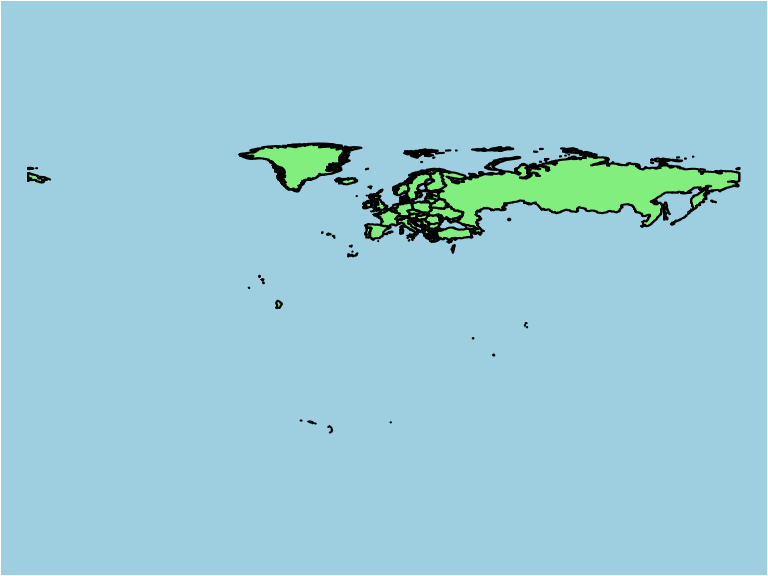

```r
par(mar=c(0,0,0,0))     # Set 0 margins
europe <- worldmap[which(worldmap$REGION=="Europe"),]
plot(europe, col="lightgreen", bg="lightblue")
```

This looks a little weird because of Russia and the inclusion of the island territories.

## Europe excluding Russia and Territories

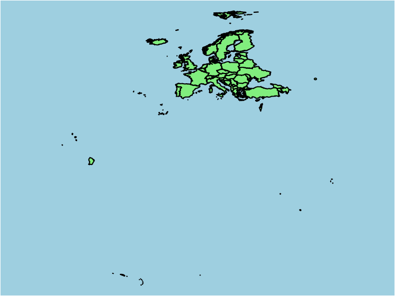

```r
par(mar=c(0,0,0,0))
europe <- worldmap[which(grepl("Europe", worldmap$GEO3) &
                             as.character(worldmap$NAME) != "Russia"),]
plot(europe, col="lightgreen", bg="lightblue")
```

## Zoom to an area

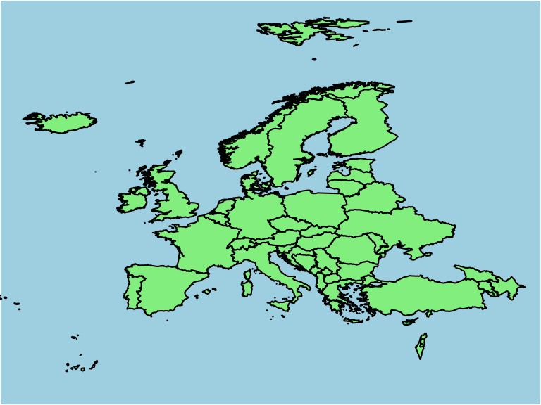

```r
par(mar=c(0,0,0,0))
plot(europe, col="lightgreen", bg="lightblue",
     xlim = c(-25, 50), ylim = c(35, 71), asp = 1)
```

## Mapping Data

## Adding Population data

First we need to load our population data:

```r
world.pop <- read.csv("../data/world.population.csv",
                  header=TRUE)
row.names(world.pop) <- world.pop[,1]
```

## Check Matching

Check which countries we do not have population data for:

```r
country.codes <- as.character(worldmap$ADM0_A3)
worldmap$ADMIN[which(!(country.codes %in%
    world.pop$CountryCode))]
```

```
##  [1] Anguilla
##  [2] Aland
##  [3] Antarctica
##  [4] Ashmore and Cartier Islands
##  [5] French Southern and Antarctic Lands
##  [6] Saint Barthelemy
##  [7] Clipperton Island
##  [8] Cyprus No Mans Area
##  [9] Cook Islands
## [10] Coral Sea Islands
## [11] Northern Cyprus
## [12] Dhekelia Sovereign Base Area
## [13] Falkland Islands
## [14] Gaza
## [15] Guernsey
```

[output cut: 28 more lines]

## Check Matching

Look for one that didn't match

```r
grep("west bank", world.pop$CountryName, ignore.case=TRUE, value=TRUE)
```

```
## [1] "West Bank and Gaza"
```

## Check Matching

Check what from the population data is not in the map data

```r
as.character(world.pop$CountryName)[
  which(!(world.pop$CountryCode %in% country.codes))]
```

```
##  [1] "Arab World"
##  [2] "Central Europe and the Baltics"
##  [3] "Channel Islands"
##  [4] "Caribbean small states"
##  [5] "East Asia & Pacific (developing only)"
##  [6] "East Asia & Pacific (all income levels)"
##  [7] "Europe & Central Asia (developing only)"
##  [8] "Europe & Central Asia (all income levels)"
##  [9] "Euro area"
## [10] "European Union"
## [11] "Fragile and conflict affected situations"
## [12] "High income"
## [13] "Heavily indebted poor countries (HIPC)"
## [14] "Not classified"
## [15] "Latin America & Caribbean (developing only)"
```

[output cut: 22 more lines]

Looks like all of the unmatched are aggregates, with a couple exceptions.

## Add the population data to the map data

```r
Pop2013 <- world.pop[,c("CountryCode", "X2013")]
colnames(Pop2013)
```

```
## [1] "CountryCode" "X2013"
```

```r
colnames(Pop2013)[2] <- "Pop2013"

worldmap$ADM0_A3 <- as.character(worldmap$ADM0_A3)
worldmap <- merge(worldmap, Pop2013,
  by.x="ADM0_A3", by.y="CountryCode", all.x=TRUE)
```

## Other options for adding data to map data

```r
joinCountryData2Map()
```

Part of the `rworldmap` package

Joins user data referenced by country codes or names to an internal map, ready for plotting using mapCountryData. Reports join successes and failures.

## Setting up to Plot

To plot population, we will give the country a color based on the population. To do this, we need to create population categories/intervals.

## Option 1

```r
quantile(worldmap$Pop2013, na.rm=TRUE)
```

```
##           0%          25%          50%          75%         100%
##       9876.0     836272.5    6333135.0   22549754.5 1357380000.0
```

```r
library(classInt)
brks <- classIntervals(worldmap$Pop2013[
    which(!is.na(worldmap$Pop2013))],
       n=10, style="quantile")
brks <- brks$brks
colors <- brewer.pal(length(brks), "RdYlBu")
```

## Option 2

```r
pop_cuts <- c(100000, 500000, 1000000, 5000000, 25000000,
              100000000, 500000000, 1000000000, 1500000000)
colors2 <- brewer.pal(length(pop_cuts) + 1, "RdYlBu")
```

## Plot the world map

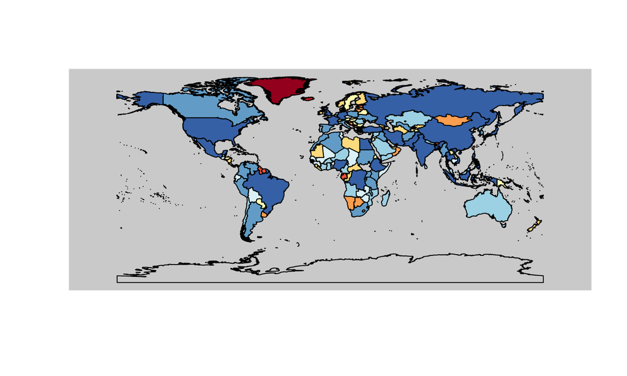

```r
plot(worldmap, col=colors[findInterval(worldmap$Pop2013,
      brks, all.inside=TRUE)], axes=FALSE, bg="lightgray")
```

This does not let us distinguish very well. We know the U.S. has a population of ~330 million, yet it is the same color as India and China, each with over 1 billion. We can define our population cuts better for this.

## Plot World Population - 2

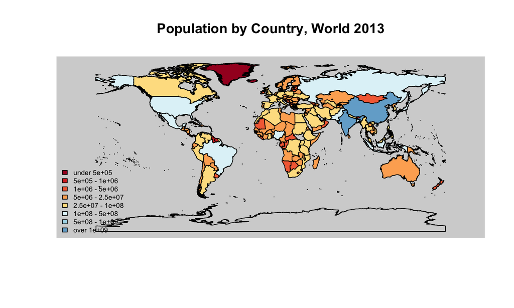

```r
plot(worldmap, col=colors2[findInterval(worldmap$Pop2013,
      pop_cuts, all.inside=TRUE)], axes=FALSE, bg="lightgray")
title("Population by Country, World 2013") #add a title
legend("bottomleft", legend=leglabs(round(pop_cuts)), #add a legend
       fill=colors2, bty="n", cex=.6)
```